# Adjunct Instruction at SLCC

## Purpose

- Present preliminary findings on adjunct instruction at SLCC.
- Get feedback from domain experts to inform additional work.

## Introduction

- Reliance on part-time faculty at community colleges has been increasing for decades as a percentage of total faculty:
  - 1969: 27%
  - 1989: 52%
  - 2007: 70%
  - 2018: nearly 80% at SLCC
- Why? Adjuncts are 80% cheaper than full-time faculty! (In 2007 the percentage of adjuncts at 4-year schools was only 32%.)
- **Key question**: Do adjuncts have a different impact on student outcomes than full-time instructors?

## Definitions

- **Adjunct**: An instructor on a temporary contract who is limited to part-time instruction during the term of the contract.
- **Full-time**: A permanent instructor who teaches full-time.
- These employment status designations are mutually exclusive within terms and exhaustive: to my knowledge there are no other possible employment options for instructors at SLCC.

## Key points from the literature

- Compared to full-time faculty, adjuncts:
  - tend to be less engaged in campus culture and less available to students (Jaeger & Eagan 2009)
  - are less likely to have an office on campus or a campus email address (Landrum 2009).
  - have almost half the years of teaching experience (Landrum 2009).
  - earn substantially less (Greenberg 2014).
  - have less academic freedom and feel more hostage to student and administrative opinions (Wilson 2010).
  - have positive impacts on grades earned in introductory courses (Ran 2017)
  - have negative impacts on subsequent course enrollment and performance (Ran 2017)
  - increased the number of subsequent classes students took in a given field, especially for fields closely tied to a profession (Bettinger & Long 2010).

## Research questions

1. **Description**: What was the nature and scope of adjunct teaching at SLCC?
2. **Grades**: Did student grades vary by faculty employment status?
3. **Retention**: Was retention into the next semester different for students who took courses largely from adjunct instructors compared to those who took courses largely from full-time instructors?
4. **Graduation**: Did students who had a high percentage of adjunct instructors, either in the first year or beyond, graduate at lower rates?
5. **Next course performance**: If students took a beginning course from an adjunct instructor was there a subsequent performance difference in the following course?

## Data notes

- Dataset consisted in one row per student course enrollment from fall 2011 through spring 2018, for a total of 20 academic terms.
- Vocational enrollments were excluded as well as concurrent enrollments.
- Only students in VFA Fall cohorts were included in the data.

## Descriptive Results

## Data discrepancy

Full-time vs. Part-time SLCC faculty by data source, Fall terms 2014 - 2016

| Data source | Term | Full-time | Part-time | Total | % part-time |
| --- | --- | --- | --- | --- | --- |
| IPEDS | Fall 2014 | 343 | 1155 | 1498 | 77.1 |
| SLCC IR | Fall 2014 | 287 | 1064 | 1351 | 78.8 |
| IPEDS | Fall 2015 | 339 | 1271 | 1610 | 78.9 |
| SLCC IR | Fall 2015 | 300 | 1049 | 1349 | 77.8 |
| IPEDS | Fall 2016 | 335 | 1242 | 1577 | 78.8 |
| SLCC IR | Fall 2016 | 294 | 1040 | 1334 | 78.0 |

## IPEDS data

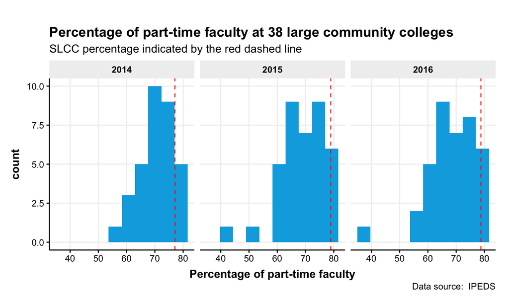

## SLCC instructor demographics

| Ethnicity | Adjunct Count | Adjunct Percent | Full-time Count | Full-time Percent |
| --- | --- | --- | --- | --- |
| American Indian or Alaska Native | 7 | 0.5 | 1 | 0.4 |
| Asian | 55 | 3.7 | 11 | 4.3 |
| Black | 35 | 2.3 | 4 | 1.6 |
| Hispanic | 67 | 4.5 | 13 | 5.1 |
| More than One | 26 | 1.7 | 6 | 2.4 |
| Pacific Islander or Native Hawaiian | 6 | 0.4 | 2 | 0.8 |
| Unknown | 33 | 2.2 | NA | NA |
| White | 1265 | 84.6 | 216 | 85.4 |

## SLCC instructor demographics

| Gender | Adjunct Count | Adjunct Percent | Full-time Count | Full-time Percent |
| --- | --- | --- | --- | --- |
| Female | 795 | 53.1 | 124 | 49 |
| Male | 701 | 46.9 | 129 | 51 |

## SLCC instructor demographics

| Age | Adjunct Count | Adjunct Percent | Full-time Count | Full-time Percent |
| --- | --- | --- | --- | --- |
| [20-30) | 170 | 11.4 | 3 | 1.2 |
| [30-40) | 517 | 34.6 | 50 | 19.8 |
| [40-50) | 334 | 22.3 | 66 | 26.1 |
| [50-60) | 226 | 15.1 | 70 | 27.7 |
| [60-70) | 189 | 12.6 | 53 | 20.9 |
| >70 | 60 | 4.0 | 11 | 4.3 |

## Scope of adjunct teaching at SLCC

- We can distinguish between the percentage of faculty that are adjunct and the percentage of *student enrollments* taught by adjuncts.
- Adjunct faculty taught about 64% of student enrollments on average while full-time faculty taught about 36%.
- Class sizes for adjuncts and full-time instructors were comparable, but adjuncts, being part time, taught fewer classes (on average, 2 per term) than did full-time faculty (4 per term).
- However, the percentage of student enrollments taught by adjuncts varied by term, with adjuncts teaching about 3% more enrollments in summer.
- The percentage of student enrollments taught by adjuncts varied by department and course.

## Percentage of Student Enrollments Taught by Adjuncts by Department

| Subject | Count | Percent |
| --- | --- | --- |
| MATH | 48638 | 58.9 |
| ENGL | 34754 | 59.9 |
| BIOL | 17312 | 55.1 |
| HLAC | 25009 | 88.6 |
| COMM | 20042 | 74.4 |
| PSY | 12784 | 56.0 |
| HIST | 13695 | 69.9 |
| MUSC | 9462 | 70.8 |
| CHEM | 7181 | 54.9 |

## Percentage of Student Enrollments Taught by Adjuncts by Course

| Course | Count | Percent |
| --- | --- | --- |
| ENGL1010 | 19436 | 70.2 |
| MATH1010 | 13581 | 64.6 |
| ENGL2010 | 11315 | 59.2 |
| HIST1700 | 11544 | 79.6 |
| COMM1010 | 13087 | 90.6 |
| MATH1050 | 6947 | 60.3 |
| PSY1010 | 6352 | 55.7 |
| HUMA1100 | 7751 | 84.9 |
| MATH990 | 4673 | 53.3 |

## Additional differences between adjunct and full-time

- Adjuncts taught 66% of the in-person students but only 51% of the online students.
- Adjuncts also taught almost 70% of the students enrollments at the 1000-2000 course level, 58% at the developmental level (< 1000), and an even smaller percentage—43%—at the 2000 level.
- The percentage of course enrollments in general education courses taught by adjuncts approached the overall average.

## Types of Adjuncts

- I categorized adjuncts into groups based on length of service:
  - short-term: those who taught only 1 term and did not teach again.
  - medium-term: those who taught between 2 and 5 terms and did not teach again.
  - long-term: those who taught more than 5 terms.

## Summary of adjunct groups

| Adjunct group | Minimum terms | Maximum terms | Average terms | Count | Percent |
| --- | --- | --- | --- | --- | --- |
| Long term | 6 | 18 | 10.1 | 673 | 65.9 |
| Medium term | 2 | 5 | 2.8 | 211 | 20.6 |
| Short term | 1 | 1 | 1.0 | 138 | 13.5 |

## Grades

- Adjunct instructors awarded higher grades, on average, compared to full-time faculty.
- However, the raw average difference, unadjusted for other factors, was modest: 2.53 for adjuncts compared to 2.39 for full-time faculty.
- The most noticeable difference occurred at 0 and 4.
- Note: 0 includes I, W and E.

## Grades

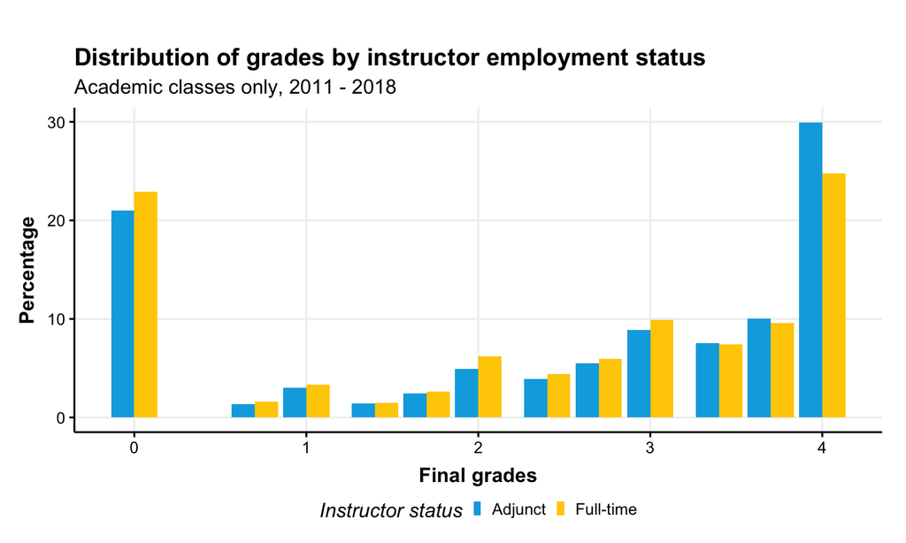

## Statistical Results

## Grades

- Did student grades differ by instructor employment status?
- There were many sources of grade variation—such as the difficulty of the course or the delivery method—that needed to be disentangled from the variation associated with instructor employment status.
- **Result**: The average difference in grades uniquely associated with instructor employment status was .07 [.02, .12], with adjuncts awarding slightly higher grades.
- However, this difference varied significantly by course.
- Courses with a large difference between full-time and adjunct grading might benefit from faculty-wide grade norming or developing shared course materials.

## Grades

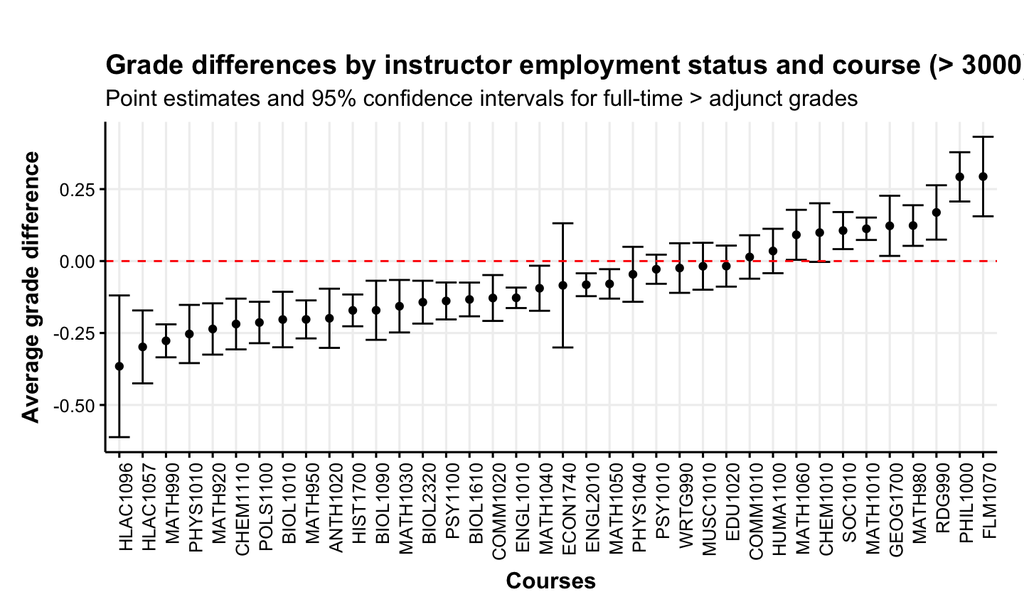

## Retention

- Did student next term retention vary by instructor employment status?
- This question was not straightforward to answer because students typically took multiple courses in any given term taught by a mix of full-time and adjunct instructors.
- So, to rephrase: Did the probability of being retained the following semester change as the proportion of courses taken from adjuncts increased?
- This question was difficult to answer because retention itself is pretty random. This makes it hard to be certain about small sources of variation in retention.

## Retention

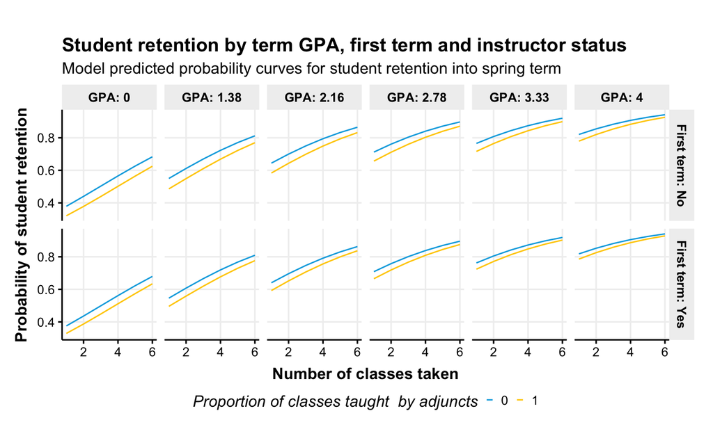

## Retention

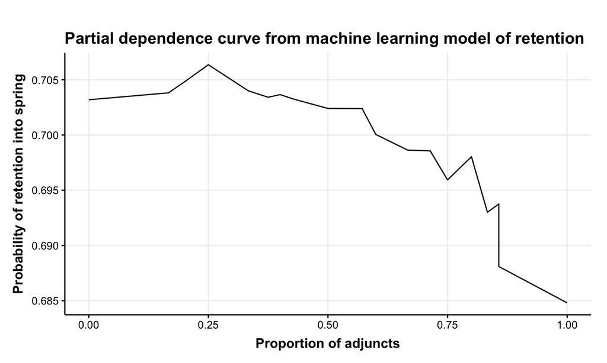

## Retention

- **Result**: The effect of adjunct teaching on retention *appears* to be real, but small, with many countervailing influences. (I am suspicious, though: The mechanism for the effect is unknown.)
- Many students do not take classes from only adjuncts or only full-time instructors, and therefore lie somewhere in between the lines in the Figure.
- Compare two average students in their first term: the first took 1 out 4 courses from an adjunct and the second who took 3 out of 4 from an adjunct.
  - The probability of returning for the next term declines by only about .025 for the second student.
  - If the same comparison is made after the first term the probability declines by only .015.

## Graduation

- Did graduation vary by adjunct teaching?
- Graduation is a career-level outcome, so we need to be more specific: Did the probability of graduating change as the proportion of career courses taken from adjuncts increased, all else being equal?
- The tricky issue here is how to define "all else being equal." Adjusting for cumulative credits was important.
- **Result**: There does not appear to be much of a relationship between adjunct instruction and graduation.

## Next course performance

- Did student performance in a sequence of courses—say, Engl1010 then Engl2010 or MATH1010 then Math1050—vary by the employment status of the first instructor when the second course was taught by a full-time instructor?
- This question is trying to get at the issue of learning, independently of grading practice.
- Additionally, what effect might adjunct instruction have had on student retention into that second course?
- **Result**: Next course performance did not appear to differ much, if at all, by the employment status of the first course instructor. The estimated effects were small and uncertain.